# Activity Report

DaniGCFH

2024-01-17

## What is mean total number of steps taken per day?

For this part of the assignment, I’ll first read the data and process it to have a view on the daily steps as shown in the histogram.

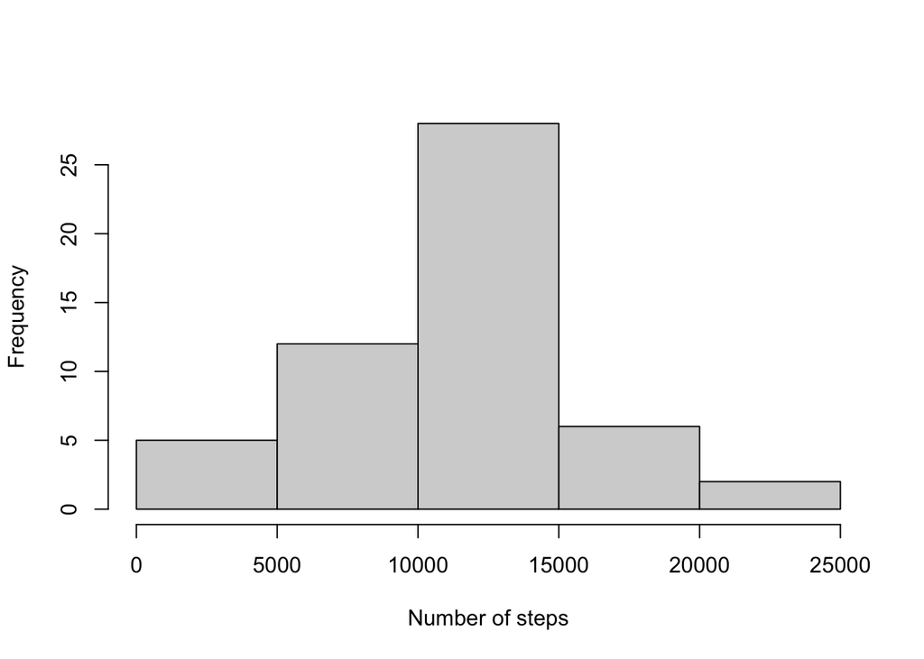

The median number of steps taken is 1.0765^{4}and the mean number of steps taken is 1.0766189^{4}

## What is the average daily activity pattern?

For this part of the assignment, I repeated the data processing, this time by interval, to produce the required plot.

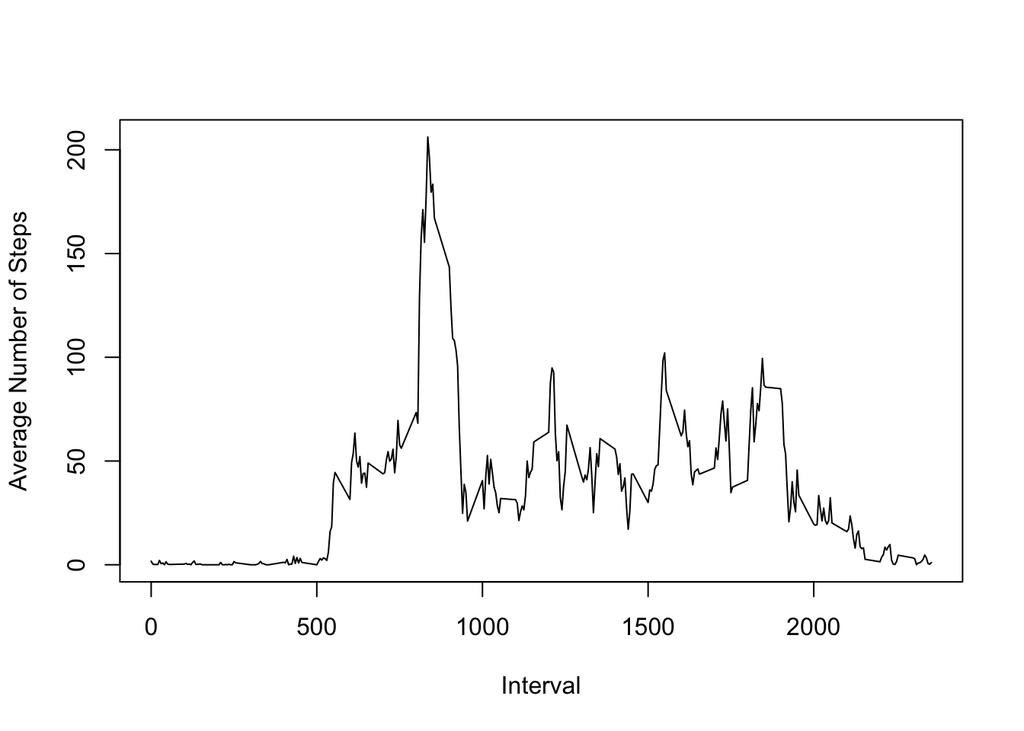

The 5 minute interval with the maximum average number of steps accross all the days in the dataset is the interval number 835

## Imputing missing values

The number of rows with missing values is 2304

To fill the missing values in the dataset, I replaced all missing values for the average number of steps per interval.

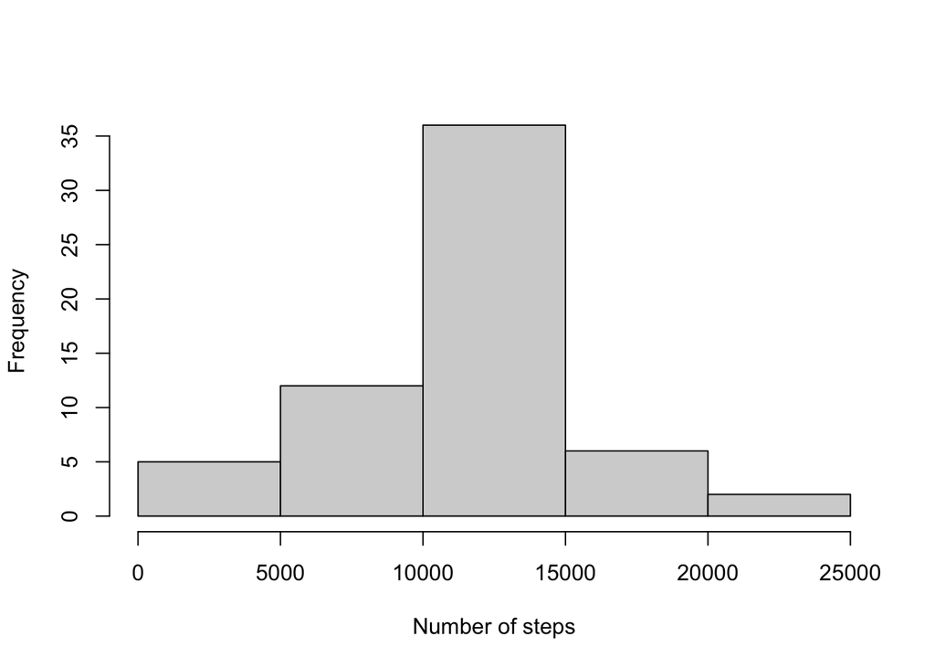

The median number of steps taken is 1.0766189^{4} and the mean number of steps taken is 1.0766189^{4}

These results are very close from the initial results, but differ in that the median value now is equal to the mean value.

## Are there differences in activity patterns between weekdays and weekends?

For this part of the assignment, I repeated the data processing while subsetting the database between weekdays and weekends.

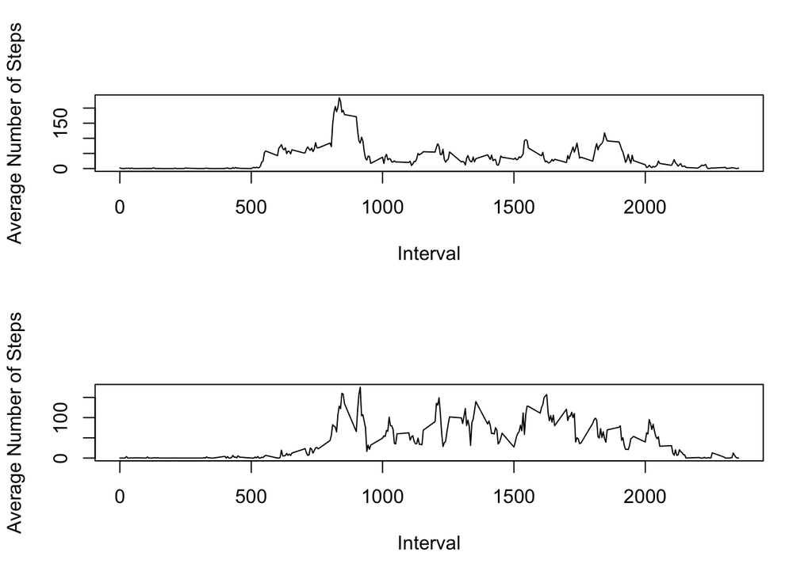

The plot show that the weekdays have a single peak in steps while the weekends seem to have multiple peaks accros the day